# Effects of self-compassion on PTG and PTST?

[Corrado Caudek](https://ccaudek.github.io/)

First version 2020-01-12. Last modified 2020-01-15

# Aim

The purpose of the study is to evaluate the Self-compassion Scale (SCS) in the context of the prediction of Post-Traumatic Growth (PTG) and PTSD in a sample of rescue workers.

Recent literature has questioned the SCS by hypothesizing that the good performance of the SCS as a protective factor against various forms of psychopathy may be mainly driven by the negative component of the SCS, which is strongly associated with the personality trait of neuroticism. Therefore, it has been asked whether the positive component of the SCS adds something to a generic dimension of *negative affect*. More specifically, Pfattheicher et al. (2017) have asked whether the negative component of the SCS can be considered as completely redundant with the personality trait of neuroticism, which is widely regarded as a vulnerability marker for psychopathology (Ormel et al. 2013).

Most of the previous studies which have investigated these issues have been carried out by considering samples from the general populations. It make sense to think that the effects of a protective factors are more easily examined in situations in which protective factors play an important role. For this reason, we have chosen to examine the above described issue by considering a large sample of individuals that may be considered “at risk” of developing some form of psychopathology, that is, a sample of rescue workers.

# Prelims

```
## here() starts at /Users/corrado/Dropbox/papers/self_compassion
```

```r
# Read data
temp <- read.csv(
  file = here("data", "rescue_workers.csv"),
  header = TRUE,
  sep = ";"
)
```

# Check for outliers

```r
tmp <- df %>%
  dplyr::select(
    life_appreciation, new_possibilities,
    personal_strength, spirituality_changes,
    interpersonal_relationships,
    avoidance, intrusion, hyperarousal,
    social_support, avoiding_strategies,
    positive_attitude, problem_orientation,
    transcendent_orientation,
    family, friends, significant_other,
    self_judgment, isolation, over_identification,
    self_kindness, common_humanity, mindfulness
  )

d2mydata <- psych::outlier(tmp, cex=.6, bad=5)
```

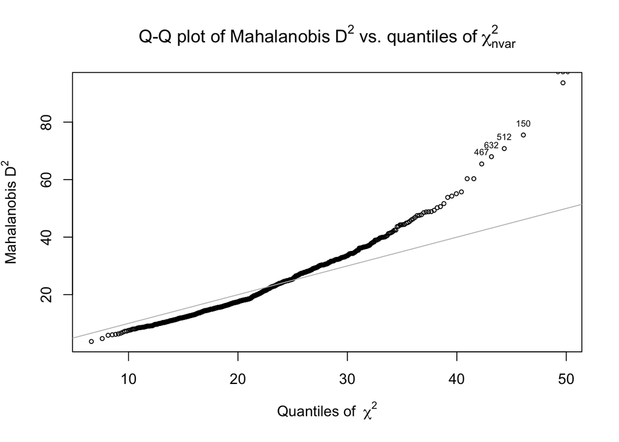

Remove 1 extreme observation.

```r
# df <- df[-c(680, 150, 512, 632, 467), ]
df <- df[-c(680), ]
```

# Model 1

M1 includes a *single compoment for self-compassion* (i.e., it does not distinguish between positive and negative self-compassion).

```r
M1 <- "
  # post-traumatic growth
  ptg =~ NA*life_appreciation + new_possibilities +
         personal_strength + spirituality_changes +
         interpersonal_relationships

  # Posttraumatic Stress Syndrome (PTSS)
  ptss =~ NA*avoidance + intrusion + hyperarousal

  # coping
  cope =~ NA*social_support + avoiding_strategies +
          positive_attitude + problem_orientation +
          transcendent_orientation

  # self-compassion
  sc =~ NA*self_judgment + isolation + over_identification +
        self_kindness + common_humanity + mindfulness

  # perceived social support
  soc =~ NA*family + friends + significant_other

  # fix variance of latent factors
  ptg  ~~ 1*ptg
  ptss ~~ 1*ptss
  cope ~~ 1*cope
  soc  ~~ 1*soc
  sc   ~~ 1*sc

  # regressions
  ptg  ~ cope + soc + sc
  ptss ~ cope + soc + sc
"
```

Fit of M1.

```r
fit1 <- lavaan::sem(
  M1,
  data = df
)
```

```r
summary(
  fit1,
  standardized = TRUE,
  fit.measures = TRUE,
  rsquare = TRUE
)
```

```
## lavaan 0.6-5 ended normally after 51 iterations
##
##   Estimator                                         ML
##   Optimization method                           NLMINB
##   Number of free parameters                         54
##
##   Number of observations                           776
##
## Model Test User Model:
##
##   Test statistic                              2274.962
##   Degrees of freedom                               199
##   P-value (Chi-square)                           0.000
##
## Model Test Baseline Model:
##
##   Test statistic                              9098.859
##   Degrees of freedom                               231
##   P-value                                        0.000
##
## User Model versus Baseline Model:
##
##   Comparative Fit Index (CFI)                    0.766
##   Tucker-Lewis Index (TLI)                       0.728
##
## Loglikelihood and Information Criteria:
##
##   Loglikelihood user model (H0)             -48619.046
##   Loglikelihood unrestricted model (H1)     -47481.565
##
##   Akaike (AIC)                               97346.093
##   Bayesian (BIC)                             97597.417
##   Sample-size adjusted Bayesian (BIC)        97425.941
##
## Root Mean Square Error of Approximation:
##
##   RMSEA                                          0.116
##   90 Percent confidence interval - lower         0.112
##   90 Percent confidence interval - upper         0.120
##   P-value RMSEA <= 0.05                          0.000
```

[output cut: 103 more lines]

```
##     hyperarousal      0.772
##     social_support    0.110
##     avoidng_strtgs    0.001
##     positive_atttd    0.485
##     problem_ornttn    0.501
##     trnscndnt_rntt    0.001
##     self_judgment     0.540
##     isolation         0.775
##     over_identfctn    0.835
##     self_kindness     0.076
##     common_humanty    0.001
##     mindfulness       0.119
##     family            0.495
##     friends           0.533
##     significnt_thr    0.548
```

Fit indices are inadequate:

```r
fitMeasures(fit1, c("chisq", "df", "cfi", "tli", "rmsea", "srmr"))
```

```
##    chisq       df      cfi      tli    rmsea     srmr
## 2274.962  199.000    0.766    0.728    0.116    0.129
```

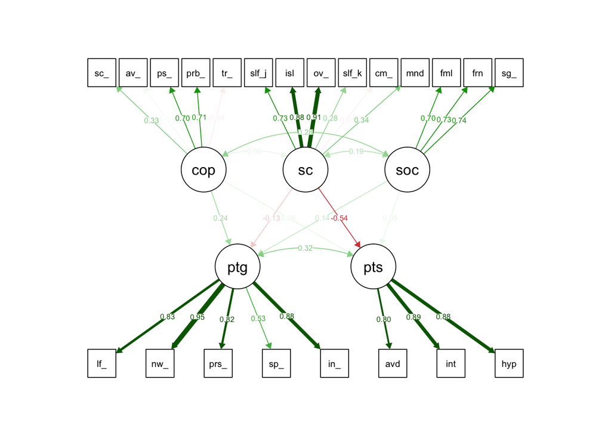

```r
semPaths(
  fit1,
  curvePivot = FALSE,
  what = "std",
  title = FALSE,
  residuals = FALSE
)
```

Examine modification indices.

```r
modificationindices(
  fit1,
  minimum.value = 20
) # only print MIs > 20
```

```
##                             lhs op                      rhs      mi    epc
## 63                          ptg =~           social_support  50.119  1.847
## 71                          ptg =~            self_kindness  56.373  1.099
## 72                          ptg =~          common_humanity  36.010  0.707
## 82                         ptss =~           social_support  90.969  2.142
## 83                         ptss =~      avoiding_strategies  71.981  1.377
## 104                        cope =~            self_judgment  24.747 -0.732
## 107                        cope =~            self_kindness 110.753  1.902
## 108                        cope =~          common_humanity  84.245  1.336
## 109                        cope =~              mindfulness 147.767  1.587
## 121                          sc =~           social_support 100.378 -2.645
## 122                          sc =~      avoiding_strategies 159.580 -2.411
## 124                          sc =~      problem_orientation  30.518  1.157
## 126                          sc =~                   family  20.828  0.807
## 137                         soc =~           social_support  59.635  2.368
```

[output cut: 57 more lines]

The indicators `avoiding_strategies` and `transcendent_orientation` are not significant and have very high modification indices. Therefore, Model 2 removes `avoiding_strategies`, `transcendent_orientation`, and `social_support`.

# Model 2

```r
M2 <- "
  # post-traumatic growth
  ptg =~ NA*life_appreciation + new_possibilities +
         personal_strength + spirituality_changes +
         interpersonal_relationships

  # Posttraumatic Stress Syndrome (PTSS)
  ptss =~ NA*avoidance + intrusion + hyperarousal

  # coping
  cope =~ NA*positive_attitude + problem_orientation

  # self-compassion
  sc =~ NA*self_judgment + isolation + over_identification +
        self_kindness + common_humanity + mindfulness

  # perceived social support
  soc =~ NA*family + friends + significant_other

  # fix variance of latent factors
  ptg  ~~ 1*ptg
  ptss ~~ 1*ptss
  cope ~~ 1*cope
  soc  ~~ 1*soc
  sc   ~~ 1*sc

  # regressions
  ptg  ~ cope + soc + sc
  ptss ~ cope + soc + sc
"
```

Fit of M2.

```r
fit2 <- lavaan::sem(
  M2,
  data = df
)
```

Models comparison:

```r
vuongtest(fit1, fit2)
```

```
##
## Model 1
##  Class: lavaan
##  Call: lavaan::lavaan(model = M1, data = df, model.type = "sem", int.ov.free = TRUE, ...
##
## Model 2
##  Class: lavaan
##  Call: lavaan::lavaan(model = M2, data = df, model.type = "sem", int.ov.free = TRUE, ...
##
## Variance test
##   H0: Model 1 and Model 2 are indistinguishable
##   H1: Model 1 and Model 2 are distinguishable
##     w2 = 2.269,   p = 4.1e-09
##
## Non-nested likelihood ratio test
##   H0: Model fits are equal for the focal population
##   H1A: Model 1 fits better than Model 2
##     z = -171.030,   p = 1
##   H1B: Model 2 fits better than Model 1
##     z = -171.030,   p = < 2.2e-16
```

The models M1 and M2 are not nested. Therefore, they cannot be compared with a likelihood-ratio test. Not-nested models can be compared with the Vuong test. The Vuong test has two components. The *variance test* determine whether the models are distinguishable in the focal population. The *non-nested likelihood ratio test* provides a comparison between the fit of the two models.

In the present case, the Vuong test indicates that the changes that had been introduced produce an improve of fit, but the fit is still not adequate.

```r
fitMeasures(fit2, c("chisq", "df", "cfi", "tli", "rmsea", "srmr"))
```

```
##    chisq       df      cfi      tli    rmsea     srmr
## 1384.218  142.000    0.844    0.813    0.106    0.105
```

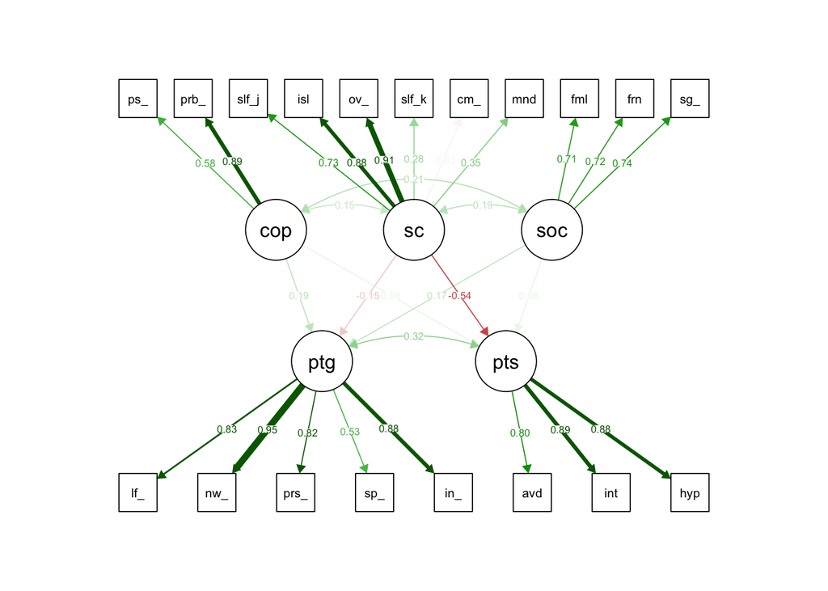

```r
semPaths(
  fit2,
  curvePivot = FALSE,
  what = "std",
  title = FALSE,
  residuals = FALSE
)
```

# Model 3

M3 distinguishes between the two (correlated) components of self-compassion: positive and negative self-compassion.

```r
M3 <- "
  # post-traumatic growth
  ptg =~ NA*life_appreciation + new_possibilities +
         personal_strength + spirituality_changes +
         interpersonal_relationships

  # ptsd
  ptss =~ NA*avoidance + intrusion + hyperarousal

  # coping
  cope =~ NA*positive_attitude + problem_orientation

  # self-compassion
  nsc =~ NA*self_judgment + isolation + over_identification
  psc =~ NA*self_kindness + common_humanity + mindfulness

  # perceived social support
  soc =~ NA*family + friends + significant_other

  # regressions
  ptg  ~ cope + soc + nsc + psc
  ptss ~ cope + soc + nsc + psc

  # fix variance of latent factors
  ptg  ~~ 1*ptg
  ptss ~~ 1*ptss
  cope ~~ 1*cope
  soc  ~~ 1*soc
  nsc  ~~ 1*nsc
  psc  ~~ 1*psc

  # covariances
  psc ~~ nsc
"
```

Fit of M3.

```r
fit3 <- lavaan::sem(
  M3,
  data = df
)
```

```r
fitMeasures(fit3, c("chisq", "df", "cfi", "tli", "rmsea", "srmr"))
```

```
##   chisq      df     cfi     tli   rmsea    srmr
## 716.441 137.000   0.927   0.909   0.074   0.059
```

Fit indices improves and now they are adequate.

```r
anova(fit2, fit3)
```

```
## Chi-Squared Difference Test
##
##       Df   AIC   BIC   Chisq Chisq diff Df diff Pr(>Chisq)
## fit3 137 82322 82569  716.44
## fit2 142 82980 83204 1384.22     667.78       5  < 2.2e-16 ***
## ---
## Signif. codes:  0 '***' 0.001 '**' 0.01 '*' 0.05 '.' 0.1 ' ' 1
```

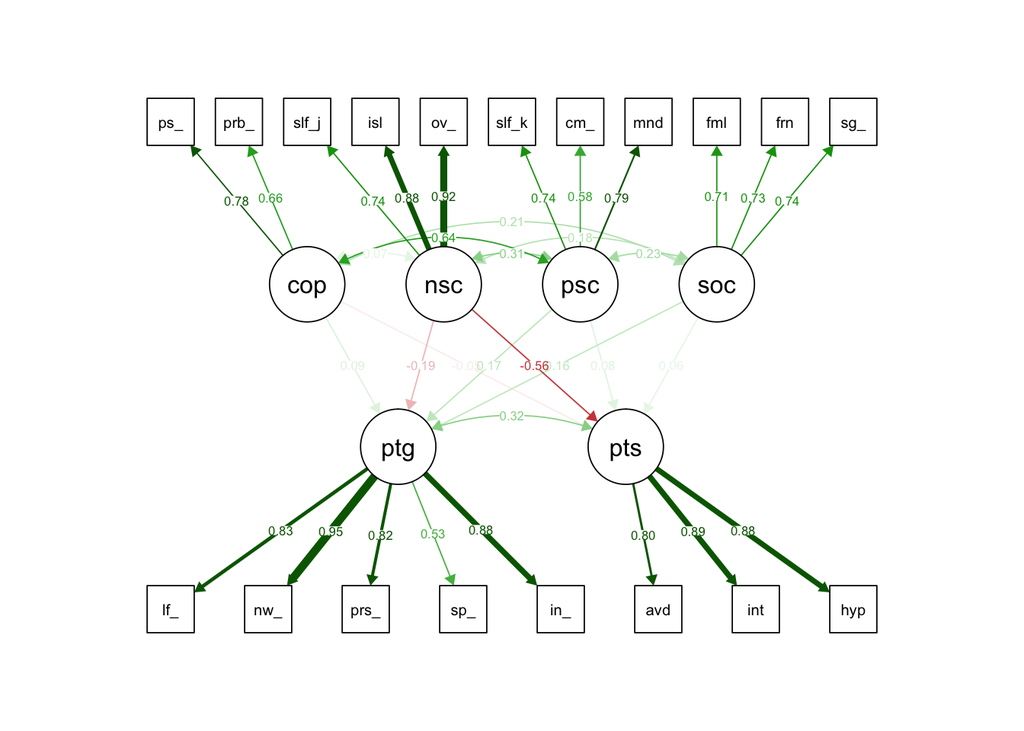

```r
semPaths(
  fit3,
  curvePivot = FALSE,
  what = "std",
  title = FALSE,
  residuals = FALSE
)
```

# Model 5

M5 is the same as M3, but it adds a covariance between two residual components of self-compassion: `self_judgment ~~ self_kindness`:

```r
M5 <- "
  # post-traumatic growth
  ptg =~ NA*life_appreciation + new_possibilities +
         personal_strength + spirituality_changes +
         interpersonal_relationships

  # ptsd
  ptss =~ NA*avoidance + intrusion + hyperarousal

  # coping
  cope =~ NA*positive_attitude + problem_orientation

  # self-compassion
  nsc =~ NA*self_judgment + isolation + over_identification
  psc =~ NA*self_kindness + common_humanity + mindfulness

  # perceived social support
  soc =~ NA*family + friends + significant_other

  # regressions
  ptg  ~ cope + soc + nsc + psc
  ptss ~ cope + soc + nsc + psc

  # fix variance of latent factors
  ptg  ~~ 1*ptg
  ptss ~~ 1*ptss
  cope ~~ 1*cope
  soc  ~~ 1*soc
  nsc  ~~ 1*nsc
  psc  ~~ 1*psc

  # covariances
  psc ~~ nsc
  self_judgment ~~ self_kindness
"
```

Fit of M5.

```r
fit5 <- lavaan::sem(
  M5,
  data = df
)
```

The fit improves:

```r
fitMeasures(fit5, c("chisq", "df", "cfi", "tli", "rmsea", "srmr"))
```

```
##   chisq      df     cfi     tli   rmsea    srmr
## 581.932 136.000   0.944   0.930   0.065   0.059
```

```r
anova(fit3, fit5)
```

```
## Chi-Squared Difference Test
##
##       Df   AIC   BIC  Chisq Chisq diff Df diff Pr(>Chisq)
## fit5 136 82190 82441 581.93
## fit3 137 82322 82569 716.44     134.51       1  < 2.2e-16 ***
## ---
## Signif. codes:  0 '***' 0.001 '**' 0.01 '*' 0.05 '.' 0.1 ' ' 1
```

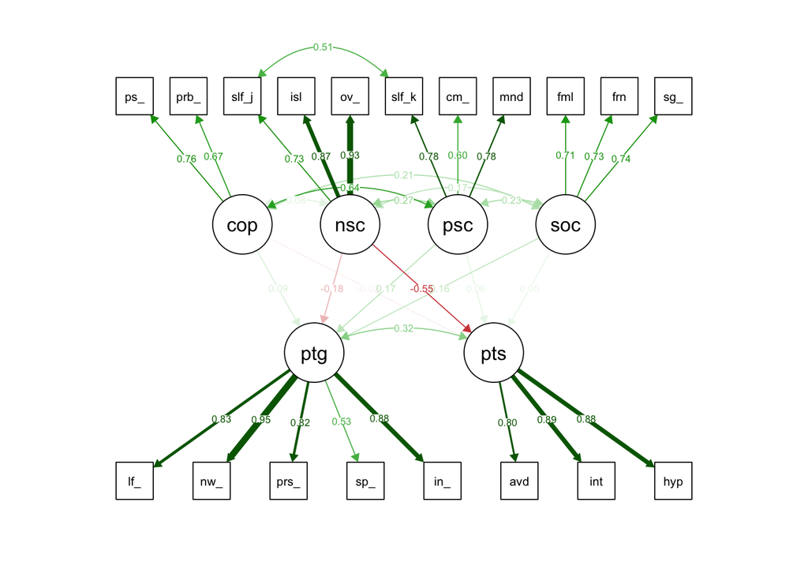

```r
semPaths(
  fit5,
  curvePivot = FALSE,
  what = "std",
  title = FALSE,
  residuals = FALSE
)
```

```r
summary(
  fit5,
  standardized = TRUE,
  fit.measures = TRUE,
  rsquare = TRUE
)
```

```
## lavaan 0.6-5 ended normally after 44 iterations
##
##   Estimator                                         ML
##   Optimization method                           NLMINB
##   Number of free parameters                         54
##
##   Number of observations                           776
##
## Model Test User Model:
##
##   Test statistic                               581.932
##   Degrees of freedom                               136
##   P-value (Chi-square)                           0.000
##
## Model Test Baseline Model:
##
##   Test statistic                              8158.581
##   Degrees of freedom                               171
##   P-value                                        0.000
##
## User Model versus Baseline Model:
##
##   Comparative Fit Index (CFI)                    0.944
##   Tucker-Lewis Index (TLI)                       0.930
##
## Loglikelihood and Information Criteria:
##
##   Loglikelihood user model (H0)             -41040.930
##   Loglikelihood unrestricted model (H1)     -40749.964
##
##   Akaike (AIC)                               82189.860
##   Bayesian (BIC)                             82441.184
##   Sample-size adjusted Bayesian (BIC)        82269.708
##
## Root Mean Square Error of Approximation:
##
##   RMSEA                                          0.065
##   90 Percent confidence interval - lower         0.060
##   90 Percent confidence interval - upper         0.070
##   P-value RMSEA <= 0.05                          0.000
```

[output cut: 105 more lines]

```
##     intrprsnl_rltn    0.781
##     avoidance         0.641
##     intrusion         0.783
##     hyperarousal      0.773
##     positive_atttd    0.584
##     problem_ornttn    0.447
##     self_judgment     0.537
##     isolation         0.751
##     over_identfctn    0.865
##     self_kindness     0.614
##     common_humanty    0.359
##     mindfulness       0.614
##     family            0.499
##     friends           0.534
##     significnt_thr    0.543
```

# Model 8

“Pfattheicher and colleagues argue the negative items of the Self-compassion Scale (SCS), which represent reduced uncompassionate self-responding, are redundant with neuroticism (especially its depression and anxiety facets) and do not evidence incremental validity in predicting life satisfaction” (Neff, Toth-Kiraly, and Colosimo, 2018). Neff et al. (2018) conclude that “although self-compassion overlaps with neuroticism, the two constructs are distinct”.

We evaluate this conclusion by adding Neuroticism to model M5.

```r
M8 <- "
  # post-traumatic growth
  ptg =~ NA*life_appreciation + new_possibilities +
         personal_strength + spirituality_changes +
         interpersonal_relationships

  # ptsd
  ptss =~ NA*avoidance + intrusion + hyperarousal

  # coping
  cope =~ NA*positive_attitude + problem_orientation

  # self-compassion
  nsc =~ NA*self_judgment + isolation + over_identification
  psc =~ NA*self_kindness + common_humanity + mindfulness

  # perceived social support
  soc =~ NA*family + friends + significant_other

  # neuroticism
  neuroticism =~ NA*negative_affect + self_reproach

  # regressions
  ptg  ~ cope + soc + nsc + psc + neuroticism
  ptss ~ cope + soc + nsc + psc + neuroticism

  # fix variance of latent factors
  ptg  ~~ 1*ptg
  ptss ~~ 1*ptss
  cope ~~ 1*cope
  soc  ~~ 1*soc
  nsc  ~~ 1*nsc
  psc  ~~ 1*psc
  neuroticism ~~ 1*neuroticism

  # covariances
  psc ~~ nsc
  self_judgment ~~ self_kindness
"
```

Fit of M8.

```r
fit8 <- lavaan::sem(
  M8,
  data = df
)
```

```r
fitMeasures(fit8, c("chisq", "df", "cfi", "tli", "rmsea", "srmr"))
```

```
##   chisq      df     cfi     tli   rmsea    srmr
## 661.032 167.000   0.946   0.932   0.062   0.059
```

```r
vuongtest(fit5, fit8)
```

```
##
## Model 1
##  Class: lavaan
##  Call: lavaan::lavaan(model = M5, data = df, model.type = "sem", int.ov.free = TRUE, ...
##
## Model 2
##  Class: lavaan
##  Call: lavaan::lavaan(model = M8, data = df, model.type = "sem", int.ov.free = TRUE, ...
##
## Variance test
##   H0: Model 1 and Model 2 are indistinguishable
##   H1: Model 1 and Model 2 are distinguishable
##     w2 = 1.370,   p = <2e-16
##
## Non-nested likelihood ratio test
##   H0: Model fits are equal for the focal population
##   H1A: Model 1 fits better than Model 2
##     z = 126.008,   p = <2e-16
##   H1B: Model 2 fits better than Model 1
##     z = 126.008,   p = 1
```

In the comparison M5 and M8, the model M5 (without Nevroticism) wins: The presence of both Neuroticism and Self-compassion produces a fit that is worse than the fit of the model with only Self-compassion.

# Model 9

The same as M8, but with only the positive component of self-compassion (`nsc` is removed).

```r
M9 <- "
  # post-traumatic growth
  ptg =~ NA*life_appreciation + new_possibilities +
         personal_strength + spirituality_changes +
         interpersonal_relationships

  # ptsd
  ptss =~ NA*avoidance + intrusion + hyperarousal

  # coping
  cope =~ NA*positive_attitude + problem_orientation

  # self-compassion
  psc =~ NA*self_kindness + common_humanity + mindfulness

  # perceived social support
  soc =~ NA*family + friends + significant_other

  # neuroticism
  neuroticism =~ NA*negative_affect + self_reproach

  # regressions
  ptg  ~ cope + soc + psc + neuroticism
  ptss ~ cope + soc + psc + neuroticism

  # fix variance of latent factors
  ptg  ~~ 1*ptg
  ptss ~~ 1*ptss
  cope ~~ 1*cope
  soc  ~~ 1*soc
  psc  ~~ 1*psc
  neuroticism ~~ 1*neuroticism
  "
```

Fit of M9.

```r
fit9 <- lavaan::sem(
  M9,
  data = df
)
```

```r
fitMeasures(fit9, c("chisq", "df", "cfi", "tli", "rmsea", "srmr"))
```

```
##   chisq      df     cfi     tli   rmsea    srmr
## 503.497 120.000   0.944   0.929   0.064   0.054
```

```r
vuongtest(fit8, fit9)
```

```
##
## Model 1
##  Class: lavaan
##  Call: lavaan::lavaan(model = M8, data = df, model.type = "sem", int.ov.free = TRUE, ...
##
## Model 2
##  Class: lavaan
##  Call: lavaan::lavaan(model = M9, data = df, model.type = "sem", int.ov.free = TRUE, ...
##
## Variance test
##   H0: Model 1 and Model 2 are indistinguishable
##   H1: Model 1 and Model 2 are distinguishable
##     w2 = 2.661,   p = <2e-16
##
## Non-nested likelihood ratio test
##   H0: Model fits are equal for the focal population
##   H1A: Model 1 fits better than Model 2
##     z = -124.596,   p = 1
##   H1B: Model 2 fits better than Model 1
##     z = -124.596,   p = < 2.2e-16
```

Better fit, in a model including Neuroticism, with only the positive component of self-compassion than with both components of self-compassion.

# Model 10

The same as M8, but with only the negative component of self-compassion (`psc` is removed).

```r
M10 <- "
  # post-traumatic growth
  ptg =~ NA*life_appreciation + new_possibilities +
         personal_strength + spirituality_changes +
         interpersonal_relationships

  # ptsd
  ptss =~ NA*avoidance + intrusion + hyperarousal

  # coping
  cope =~ NA*positive_attitude + problem_orientation

  # self-compassion
  nsc =~ NA*self_judgment + isolation + over_identification

  # perceived social support
  soc =~ NA*family + friends + significant_other

  # neuroticism
  neuroticism =~ NA*negative_affect + self_reproach

  # regressions
  ptg  ~ cope + soc + nsc + neuroticism
  ptss ~ cope + soc + nsc + neuroticism

  # fix variance of latent factors
  ptg  ~~ 1*ptg
  ptss ~~ 1*ptss
  cope ~~ 1*cope
  soc  ~~ 1*soc
  nsc  ~~ 1*nsc
  neuroticism ~~ 1*neuroticism
"
```

Fit of M10.

```r
fit10 <- lavaan::sem(
  M10,
  data = df
)
```

```r
fitMeasures(fit10, c("chisq", "df", "cfi", "tli", "rmsea", "srmr"))
```

```
##   chisq      df     cfi     tli   rmsea    srmr
## 372.476 120.000   0.968   0.959   0.052   0.038
```

```r
vuongtest(fit8, fit10)
```

```
##
## Model 1
##  Class: lavaan
##  Call: lavaan::lavaan(model = M8, data = df, model.type = "sem", int.ov.free = TRUE, ...
##
## Model 2
##  Class: lavaan
##  Call: lavaan::lavaan(model = M10, data = df, model.type = "sem", int.ov.free = TRUE, ...
##
## Variance test
##   H0: Model 1 and Model 2 are indistinguishable
##   H1: Model 1 and Model 2 are distinguishable
##     w2 = 2.225,   p = 2.02e-08
##
## Non-nested likelihood ratio test
##   H0: Model fits are equal for the focal population
##   H1A: Model 1 fits better than Model 2
##     z = -139.586,   p = 1
##   H1B: Model 2 fits better than Model 1
##     z = -139.586,   p = < 2.2e-16
```

```r
vuongtest(fit9, fit10)
```

```
##
## Model 1
##  Class: lavaan
##  Call: lavaan::lavaan(model = M9, data = df, model.type = "sem", int.ov.free = TRUE, ...
##
## Model 2
##  Class: lavaan
##  Call: lavaan::lavaan(model = M10, data = df, model.type = "sem", int.ov.free = TRUE, ...
##
## Variance test
##   H0: Model 1 and Model 2 are indistinguishable
##   H1: Model 1 and Model 2 are distinguishable
##     w2 = 3.944,   p = <2e-16
##
## Non-nested likelihood ratio test
##   H0: Model fits are equal for the focal population
##   H1A: Model 1 fits better than Model 2
##     z = -2.510,   p = 0.994
##   H1B: Model 2 fits better than Model 1
##     z = -2.510,   p = 0.006039
```

Better fit, in a model including Neuroticism, with only the negative component of self-compassion than with both components of self-compassion.

# Model 11

The model M11 removes both components of self-compassion: The exogenous variables are Neuroticism, Coping, and Perceived Social Support.

```r
M11 <- "
  # post-traumatic growth
  ptg =~ NA*life_appreciation + new_possibilities +
         personal_strength + spirituality_changes +
         interpersonal_relationships

  # ptss
  ptss =~ NA*avoidance + intrusion + hyperarousal

  # coping
  cope =~ NA*positive_attitude + problem_orientation

  # perceived social support
  soc =~ NA*family + friends + significant_other

  # neuroticism
  neuroticism =~ NA*negative_affect + self_reproach

  # regressions
  ptg  ~ cope + soc + neuroticism
  ptss ~ cope + soc + neuroticism

  # fix variance of latent factors
  ptg  ~~ 1*ptg
  ptss ~~ 1*ptss
  cope ~~ 1*cope
  soc  ~~ 1*soc
  neuroticism ~~ 1*neuroticism
"
```

Fit of M11.

```r
fit11 <- lavaan::sem(
  M11,
  data = df
)
```

```r
fitMeasures(fit11, c("chisq", "df", "cfi", "tli", "rmsea", "srmr"))
```

```
##   chisq      df     cfi     tli   rmsea    srmr
## 245.456  80.000   0.972   0.963   0.052   0.034
```

```r
residuals(fit11, type="cor")
```

```
## $type
## [1] "cor.bollen"
##
## $cov
##                             lf_ppr nw_pss prsnl_ sprtl_ intrp_ avodnc intrsn
## life_appreciation            0.000
## new_possibilities            0.000  0.000
## personal_strength           -0.007  0.010  0.000
## spirituality_changes        -0.024  0.013 -0.075  0.000
## interpersonal_relationships  0.006 -0.006 -0.003  0.037  0.000
## avoidance                    0.054  0.027  0.000  0.013  0.048  0.000
## intrusion                    0.051 -0.007 -0.019 -0.016  0.047 -0.005  0.000
## hyperarousal                -0.014 -0.024 -0.077 -0.018 -0.017  0.000  0.003
## positive_attitude            0.054  0.035  0.105  0.035  0.068  0.021  0.000
## problem_orientation         -0.019 -0.012  0.051 -0.016  0.000  0.004  0.013
## family                       0.074 -0.023  0.029  0.015  0.050 -0.029 -0.016
## friends                     -0.039 -0.051 -0.020 -0.074  0.054 -0.005  0.009
## significant_other            0.041 -0.015  0.007 -0.015  0.053  0.029  0.082
## negative_affect              0.021 -0.012 -0.043  0.050  0.041 -0.004 -0.008
## self_reproach               -0.004 -0.016 -0.037  0.063  0.044  0.019 -0.007
##                             hyprrs pstv_t prblm_ family frinds sgnfc_ ngtv_f
## life_appreciation
## new_possibilities
## personal_strength
## spirituality_changes
## interpersonal_relationships
## avoidance
## intrusion
## hyperarousal                 0.000
## positive_attitude           -0.055  0.000
## problem_orientation         -0.013  0.000  0.000
## family                      -0.071 -0.016 -0.014  0.000
## friends                     -0.026  0.072  0.001 -0.010  0.000
## significant_other            0.011 -0.001  0.009 -0.001  0.009  0.000
## negative_affect              0.006 -0.006 -0.009 -0.050 -0.005  0.075  0.000
## self_reproach               -0.001  0.053  0.005 -0.075 -0.018  0.059  0.000
##                             slf_rp
## life_appreciation
## new_possibilities
## personal_strength
## spirituality_changes
## interpersonal_relationships
## avoidance
## intrusion
## hyperarousal
## positive_attitude
## problem_orientation
## family
## friends
## significant_other
## negative_affect
## self_reproach                0.000
```

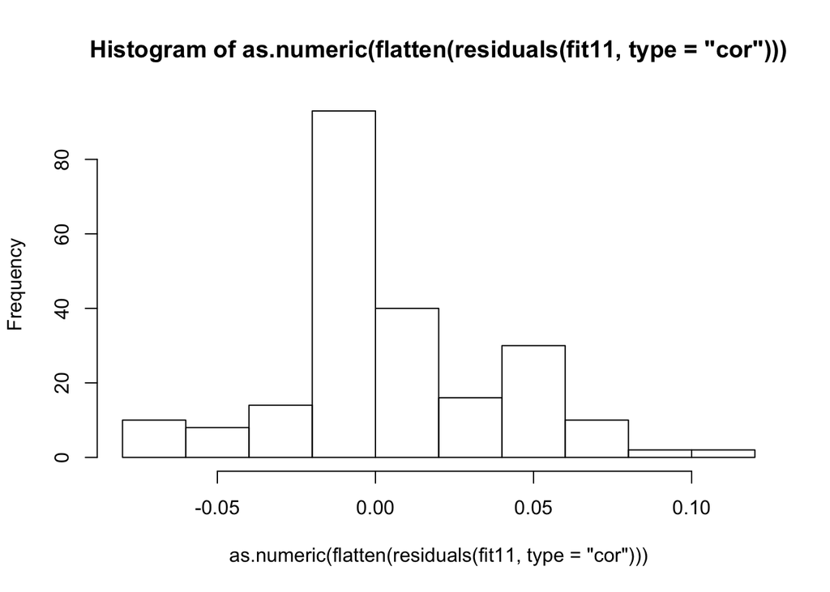

```r
hist(as.numeric(flatten(residuals(fit11, type="cor"))))
```

```r
inspect(fit11, "rsquare")
```

```
##                         ptg                        ptss
##                       0.070                       0.233
##           life_appreciation           new_possibilities
##                       0.696                       0.897
##           personal_strength        spirituality_changes
##                       0.672                       0.285
## interpersonal_relationships                   avoidance
##                       0.780                       0.640
##                   intrusion                hyperarousal
##                       0.776                       0.782
##           positive_attitude         problem_orientation
##                       0.276                       0.946
##                      family                     friends
##                       0.498                       0.527
##           significant_other             negative_affect
##                       0.551                       0.602
##               self_reproach
##                       0.672
```

Let’s compare the models with either the two components of self-compassion, or Neuroticism.

```r
vuongtest(fit5, fit11)
```

```
##
## Model 1
##  Class: lavaan
##  Call: lavaan::lavaan(model = M5, data = df, model.type = "sem", int.ov.free = TRUE, ...
##
## Model 2
##  Class: lavaan
##  Call: lavaan::lavaan(model = M11, data = df, model.type = "sem", int.ov.free = TRUE, ...
##
## Variance test
##   H0: Model 1 and Model 2 are indistinguishable
##   H1: Model 1 and Model 2 are distinguishable
##     w2 = 5.182,   p = <2e-16
##
## Non-nested likelihood ratio test
##   H0: Model fits are equal for the focal population
##   H1A: Model 1 fits better than Model 2
##     z = -117.073,   p = 1
##   H1B: Model 2 fits better than Model 1
##     z = -117.073,   p = < 2.2e-16
```

The model including Neuroticism fits better that the model with the two components of self-compassion.

```r
summary(
  fit11,
  standardized = TRUE,
  fit.measures = TRUE,
  rsquare = TRUE
)
```

```
## lavaan 0.6-5 ended normally after 38 iterations
##
##   Estimator                                         ML
##   Optimization method                           NLMINB
##   Number of free parameters                         40
##
##   Number of observations                           776
##
## Model Test User Model:
##
##   Test statistic                               245.456
##   Degrees of freedom                                80
##   P-value (Chi-square)                           0.000
##
## Model Test Baseline Model:
##
##   Test statistic                              5942.483
##   Degrees of freedom                               105
##   P-value                                        0.000
##
## User Model versus Baseline Model:
##
##   Comparative Fit Index (CFI)                    0.972
##   Tucker-Lewis Index (TLI)                       0.963
##
## Loglikelihood and Information Criteria:
##
##   Loglikelihood user model (H0)             -33616.762
##   Loglikelihood unrestricted model (H1)     -33494.034
##
##   Akaike (AIC)                               67313.523
##   Bayesian (BIC)                             67499.689
##   Sample-size adjusted Bayesian (BIC)        67372.670
##
## Root Mean Square Error of Approximation:
##
##   RMSEA                                          0.052
##   90 Percent confidence interval - lower         0.044
##   90 Percent confidence interval - upper         0.059
##   P-value RMSEA <= 0.05                          0.346
```

[output cut: 82 more lines]

```
##     life_apprecitn    0.696
##     new_possibilts    0.897
##     persnl_strngth    0.672
##     spirtlty_chngs    0.285
##     intrprsnl_rltn    0.780
##     avoidance         0.640
##     intrusion         0.776
##     hyperarousal      0.782
##     positive_atttd    0.276
##     problem_ornttn    0.946
##     family            0.498
##     friends           0.527
##     significnt_thr    0.551
##     negative_affct    0.602
##     self_reproach     0.672
```

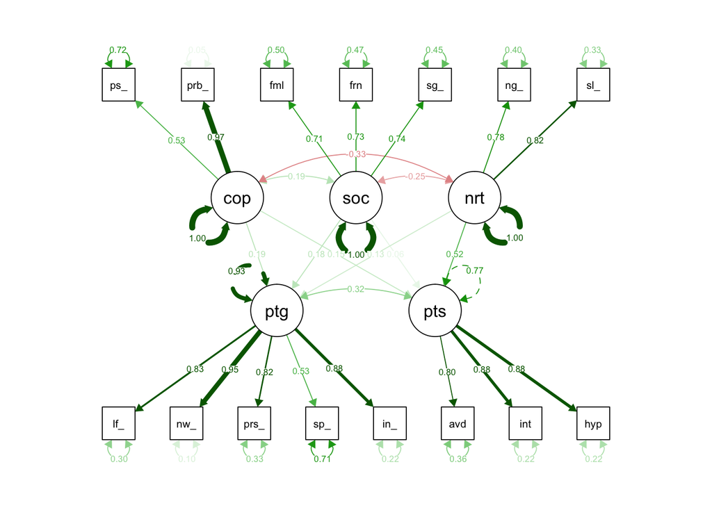

```r
semPaths(
  fit11,
  curvePivot = FALSE,
  what = "std",
  title = FALSE,
  residuals = TRUE
)
```

# Model 12

Self-compassion as a moderator

```r
M12 <- "
  # post-traumatic growth
  ptg =~ NA*life_appreciation + new_possibilities +
         personal_strength + spirituality_changes +
         interpersonal_relationships

  # ptss
  ptss =~ NA*avoidance + intrusion + hyperarousal

  # coping
  cope =~ NA*positive_attitude + problem_orientation

  # perceived social support
  soc =~ NA*family + friends + significant_other

  # neuroticism
  neuroticism =~ NA*negative_affect + self_reproach

  # self-compassion
  nsc =~ NA*self_judgment + isolation + over_identification
  psc =~ NA*self_kindness + common_humanity + mindfulness

  # regressions

  ptg  ~ psc + nsc
  ptss ~ psc + nsc
  psc  ~ cope + soc + neuroticism
  nsc ~ cope + soc + neuroticism
  ptg  ~ cope + soc + neuroticism
  ptss ~ cope + soc + neuroticism

  # fix variance of latent factors
  ptg  ~~ 1*ptg
  ptss ~~ 1*ptss
  cope ~~ 1*cope
  soc  ~~ 1*soc
  neuroticism ~~ 1*neuroticism
  psc  ~~ 1*psc
  nsc  ~~ 1*nsc

  # covariances
  psc ~~ nsc
  self_judgment ~~ self_kindness
"
```

Fit of M12.

```r
fit12 <- lavaan::sem(
  M12,
  data = df
)
```

```r
fitMeasures(fit12, c("chisq", "df", "cfi", "tli", "rmsea", "srmr"))
```

```
##   chisq      df     cfi     tli   rmsea    srmr
## 661.032 167.000   0.946   0.932   0.062   0.059
```

```r
vuongtest(fit11, fit12)
```

```
##
## Model 1
##  Class: lavaan
##  Call: lavaan::lavaan(model = M11, data = df, model.type = "sem", int.ov.free = TRUE, ...
##
## Model 2
##  Class: lavaan
##  Call: lavaan::lavaan(model = M12, data = df, model.type = "sem", int.ov.free = TRUE, ...
##
## Variance test
##   H0: Model 1 and Model 2 are indistinguishable
##   H1: Model 1 and Model 2 are distinguishable
##     w2 = 5.441,   p = 2.12e-08
##
## Non-nested likelihood ratio test
##   H0: Model fits are equal for the focal population
##   H1A: Model 1 fits better than Model 2
##     z = 177.496,   p = <2e-16
##   H1B: Model 2 fits better than Model 1
##     z = 177.496,   p = 1
```

The model with self-compassion as moderator produces a worst fit than the model without this moderator.

```r
summary(
  fit12,
  standardized = TRUE,
  fit.measures = TRUE,
  rsquare = TRUE
)
```

```
## lavaan 0.6-5 ended normally after 58 iterations
##
##   Estimator                                         ML
##   Optimization method                           NLMINB
##   Number of free parameters                         64
##
##   Number of observations                           776
##
## Model Test User Model:
##
##   Test statistic                               661.032
##   Degrees of freedom                               167
##   P-value (Chi-square)                           0.000
##
## Model Test Baseline Model:
##
##   Test statistic                              9285.746
##   Degrees of freedom                               210
##   P-value                                        0.000
##
## User Model versus Baseline Model:
##
##   Comparative Fit Index (CFI)                    0.946
##   Tucker-Lewis Index (TLI)                       0.932
##
## Loglikelihood and Information Criteria:
##
##   Loglikelihood user model (H0)             -45150.159
##   Loglikelihood unrestricted model (H1)     -44819.643
##
##   Akaike (AIC)                               90428.318
##   Bayesian (BIC)                             90726.183
##   Sample-size adjusted Bayesian (BIC)        90522.953
##
## Root Mean Square Error of Approximation:
##
##   RMSEA                                          0.062
##   90 Percent confidence interval - lower         0.057
##   90 Percent confidence interval - upper         0.067
##   P-value RMSEA <= 0.05                          0.000
```

[output cut: 124 more lines]

```
##     intrusion         0.782
##     hyperarousal      0.773
##     positive_atttd    0.532
##     problem_ornttn    0.491
##     family            0.500
##     friends           0.533
##     significnt_thr    0.542
##     negative_affct    0.505
##     self_reproach     0.802
##     self_judgment     0.536
##     isolation         0.777
##     over_identfctn    0.842
##     self_kindness     0.608
##     common_humanty    0.349
##     mindfulness       0.624
```

# Model 13

Neef suggests to adapt a bifactor model to the self-compassion scale. Therefore, we consider a bifactor model for self-compassion, together with Neuroticism.

```r
M13 <- "
  # post-traumatic growth
  ptg =~ NA*life_appreciation + new_possibilities +
         personal_strength + spirituality_changes +
         interpersonal_relationships

  # ptsd
  ptss =~ NA*avoidance + intrusion + hyperarousal

  # coping
  cope =~ NA*positive_attitude + problem_orientation

  # self-compassion: bifactor
  nsc =~ NA*self_judgment + isolation + over_identification
  psc =~ NA*self_kindness + common_humanity + mindfulness
  sc  =~ NA*self_kindness + common_humanity + mindfulness +
         self_judgment + isolation + over_identification

  # perceived social support
  soc =~ NA*family + friends + significant_other

  # neuroticism
  neuroticism =~ NA*negative_affect + self_reproach

  # regressions
  ptg  ~ cope + soc + nsc + psc + neuroticism
  ptss ~ cope + soc + nsc + psc + neuroticism

  # fix variance of latent factors
  ptg  ~~ 1*ptg
  ptss ~~ 1*ptss
  cope ~~ 1*cope
  soc  ~~ 1*soc
  nsc  ~~ 1*nsc
  psc  ~~ 1*psc
  sc   ~~ 1*sc
  neuroticism ~~ 1*neuroticism

  # covariances
  psc ~~ 0*nsc
  sc  ~~ 0*nsc
  sc  ~~ 0*psc
  self_judgment ~~ self_kindness
"
```

Fit of M13.

```r
fit13 <- lavaan::sem(
  M13,
  data = df
)
```

```r
fitMeasures(fit13, c("chisq", "df", "cfi", "tli", "rmsea", "srmr"))
```

```
##   chisq      df     cfi     tli   rmsea    srmr
## 512.747 159.000   0.961   0.949   0.054   0.043
```

A first comparison is between the model with the two components of self-compassion and Nevroticism (plus coping and perceived social support) and the model with the bifactor structure of self-compassion and Nevroticism (plus coping and perceived social support).

```r
vuongtest(fit8, fit13)
```

```
##
## Model 1
##  Class: lavaan
##  Call: lavaan::lavaan(model = M8, data = df, model.type = "sem", int.ov.free = TRUE, ...
##
## Model 2
##  Class: lavaan
##  Call: lavaan::lavaan(model = M13, data = df, model.type = "sem", int.ov.free = TRUE, ...
##
## Variance test
##   H0: Model 1 and Model 2 are indistinguishable
##   H1: Model 1 and Model 2 are distinguishable
##     w2 = 0.213,   p = 4.47e-08
##
## Non-nested likelihood ratio test
##   H0: Model fits are equal for the focal population
##   H1A: Model 1 fits better than Model 2
##     z = -5.762,   p = 1
##   H1B: Model 2 fits better than Model 1
##     z = -5.762,   p = 4.152e-09
```

This comparison indicates that the bifactor structure fits better the self-compassion scale.

A second comparison is between the model with the bifactor structure of self-compassion, Nevroticis, Coping, and Perceived social support as exogenous variables, and the model in which self-compassion is excluded.

```r
vuongtest(fit11, fit13)
```

```
##
## Model 1
##  Class: lavaan
##  Call: lavaan::lavaan(model = M11, data = df, model.type = "sem", int.ov.free = TRUE, ...
##
## Model 2
##  Class: lavaan
##  Call: lavaan::lavaan(model = M13, data = df, model.type = "sem", int.ov.free = TRUE, ...
##
## Variance test
##   H0: Model 1 and Model 2 are indistinguishable
##   H1: Model 1 and Model 2 are distinguishable
##     w2 = 5.344,   p = <2e-16
##
## Non-nested likelihood ratio test
##   H0: Model fits are equal for the focal population
##   H1A: Model 1 fits better than Model 2
##     z = 177.949,   p = <2e-16
##   H1B: Model 2 fits better than Model 1
##     z = 177.949,   p = 1
```

The results indicate that the model *without* self-compassion fits better.

# Conclusion

Self-compassion does not improve the prediction of PTG and PTSD in a sample of rescue workers when the model includes Nevroticism. Pfattheicher and colleagues have argued that the negative items of the Self-compassion Scale (SCS), which represent reduced uncompassionate self-responding, are redundant with neuroticism and do not provide evidence of incremental validity in predicting life satisfaction. We find that this conclusion applies to both components of the SCS, not only to the negative component of the SCS, when considering the validity of predicting PTG and PTSD.